# Appendix 2. Transcript Annotation and Seasonal Gene Expression in Kidney Tissue of the Australian Pygmy Bluetongue Skink, *Tiliqua adelaidensis*

### Initial Data Exploration

```r
# Which values in myCPM are greater than 0.5?
thresh_Season4F <- myTPM_Season4F > 0.5
# This produces a logical matrix with TRUEs and FALSEs
# head(thresh_Season4F)
```

Insert colour pallate for following visualisations consistency

```r
myPalette4 <- c("#999999", "#F0E442", "#56B4E9", "#CC79A7")
```

Plot CPM distribution with logged CPM

```r
# export the plot as png
png("plotDensities_Season4F.png", width = 600)
unfilteredExpr_Season4F <- cpm(dge_Season4F, log = T)
plotDensities(unfilteredExpr_Season4F, col = myPalette4, legend = TRUE)
```

Visualise library sizes per sample

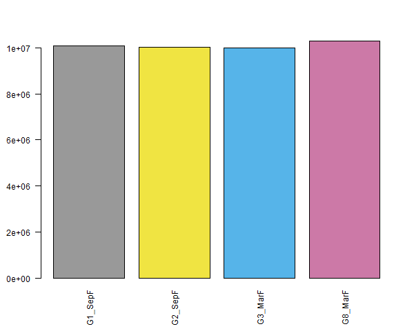

Library size of read counts calculated using Kallisto and displayed in EdgeR, for short-read poly(A) selected mRNA sequenced from kidney tissue of four female *Tiliqua adelaidensis* individuals, two collected in autumn and two collected in spring, sequenced using Illumina Hi-Seq PE short-read sequencing. Reference sequence isolated from *Tiliqua adelaidensis* skink ID: G6, a representative individual for Pacific Biosciences Iso-Seq long-read transcript sequencing and annotation to generate full length reference transcripts (note G6 was male). Season and Sex are indicated in labels: Sep = September (spring), Mar = March (autumn), F =Female, M=Male.

```r
# The names argument tells the barplot to use the sample
# names on the x-axis The las argument rotates the axis
# names export the plot as png
png("Barplot.LibSize_Season4F.png", width = 600)
barplot(dge_Season4F$samples$lib.size, names = colnames(dge_Season4F),
    las = 2, col = myPalette4)
# title('Barplot of library sizes')
```

Visualise transcript total estimated counts per sample

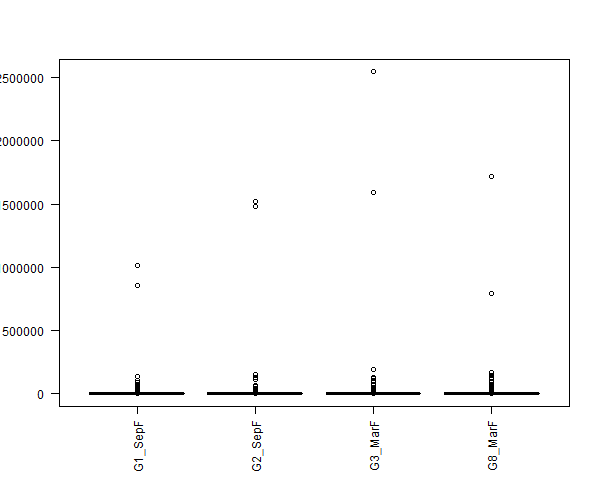

Total estimated counts, calculated using Kallisto and displayed in EdgeR, for short-read poly(A) selected mRNA sequenced from kidney tissue of four female *Tiliqua adelaidensis* individuals, two collected in autumn and two collected in spring, sequenced using Illumina Hi-Seq PE short-read sequencing. Reference sequence isolated from *Tiliqua adelaidensis* skink ID: G6, a representative individual for Pacific Biosciences Iso-Seq long-read transcript sequencing and annotation to generate full length reference transcripts (note G6 was male). Season and Sex are indicated in labels: Sep = September (spring), Mar = March (autumn), F =Female, M=Male.

```r
# export the plot as png
png("Boxplot.Counts_Season4F.png", width = 600)
boxplot(dge_Season4F$counts, col = myPalette4, las = 2, legend = TRUE)
# title('Boxplot of total unfiltered Counts')
```

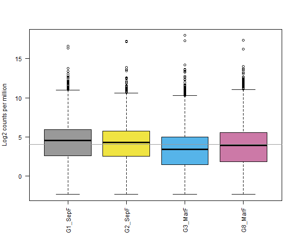

Log2 of estimated counts per million, calculated using Kallisto and displayed in EdgeR, for short-read poly(A) selected mRNA sequenced from kidney tissue of four female *Tiliqua adelaidensis* individuals, two collected in autumn and two collected in spring, sequenced using Illumina Hi-Seq PE short-read sequencing. Reference sequence isolated from *Tiliqua adelaidensis* skink ID: G6, a representative individual for Pacific Biosciences Iso-Seq long-read transcript sequencing and annotation to generate full length reference transcripts (note G6 was male). Season and Sex are indicated in labels: Sep = September (spring), Mar = March (autumn), F =Female, M=Male.

```r
# Get log2 counts per million
logcounts_Season4F <- cpm(dge_Season4F, log = TRUE)
# Check distributions of samples using boxplots export the
# plot as png
png("boxplot.CPM_Season4F.png", width = 600)
boxplot(logcounts_Season4F, xlab = "", ylab = "Log2 counts per million",
    las = 2, col = myPalette4, legend = TRUE)
# Let's add a blue horizontal line that corresponds to the
# median logCPM
abline(h = median(logcounts_Season4F), col = myPalette4, legend = TRUE)
# title('Boxplots of log Counts Per Million')
```

Visualise sample variation using an MDS plot

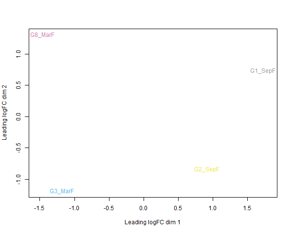

MDS plot of variation among four *T. adelaidensis* individuals. Counts calculated using Kallisto and displayed in EdgeR, for short-read poly(A) selected mRNA sequenced from kidney tissue of four female *Tiliqua adelaidensis* individuals, two collected in autumn and two collected in spring, sequenced using Illumina Hi-Seq PE short-read sequencing. Reference sequence isolated from *Tiliqua adelaidensis* skink ID: G6, a representative individual for Pacific Biosciences Iso-Seq long-read transcript sequencing and annotation to generate full length reference transcripts (note G6 was male). Season and Sex are indicated in labels: Sep = September (spring), Mar = March (autumn), F =Female, M=Male.

```r
# export the plot as png
png("MDS_Season4F.png", width = 600)
plotMDS(dge_Season4F, col = myPalette4)
# title('MDS plot')
```

### Calculations

```r
# Data with actual counts, not TPM = 'dge'
# head(dge_Season4F) head(myTPM_Season4F)
```

filter out genes with less than 5 reads in 2 samples for each transcript

```r
filter_Season4F <- apply(dge_Season4F, 1, function(x) length(x[x >
    5]) >= 2)
filtered_Season4F <- dge_Season4F[filter_Season4F, ]
head(filtered_Season4F)
```

```
## An object of class "DGEList"
## $counts
##                                                    G1_SepF    G2_SepF   G3_MarF
## PB.2.1|002537|path0:1-1624(+)|transcript/18304   278.00000  218.00000  99.00000
## PB.3.2|00361c|path0:43-2240(+)|transcript/10564 1208.00000 1143.00000 990.00000
## PB.11.1|004815|path2:1-3039(+)|transcript/3426    41.70711   53.23394  19.29667
## PB.13.1|004c10|path2:1-2811(+)|transcript/4993   108.66377   68.97787  18.89805
## PB.14.1|006283|path0:1-1955(+)|transcript/13821  964.49077  655.21013 455.87608
## PB.15.1|006e23|path0:1-3614(+)|transcript/1774   725.36411  637.30364 427.59261
##                                                    G8_MarF
## PB.2.1|002537|path0:1-1624(+)|transcript/18304   225.00000
## PB.3.2|00361c|path0:43-2240(+)|transcript/10564 2302.00000
## PB.11.1|004815|path2:1-3039(+)|transcript/3426    14.05323
## PB.13.1|004c10|path2:1-2811(+)|transcript/4993    40.63080
## PB.14.1|006283|path0:1-1955(+)|transcript/13821  716.88749
## PB.15.1|006e23|path0:1-3614(+)|transcript/1774   839.75194
##
## $samples
##         group lib.size norm.factors
## G1_SepF     1 10091726            1
## G2_SepF     1 10026494            1
## G3_MarF     2  9999768            1
## G8_MarF     2 10309597            1
##
## $genes
##                                                 Length EffectiveLength
## PB.2.1|002537|path0:1-1624(+)|transcript/18304    1530        1207.711
## PB.3.2|00361c|path0:43-2240(+)|transcript/10564   2065        1742.711
## PB.11.1|004815|path2:1-3039(+)|transcript/3426    2999        2676.711
## PB.13.1|004c10|path2:1-2811(+)|transcript/4993    2714        2391.711
## PB.14.1|006283|path0:1-1955(+)|transcript/13821   1920        1597.711
## PB.15.1|006e23|path0:1-3614(+)|transcript/1774    3583        3260.711
##                                                 Overdispersion
## PB.2.1|002537|path0:1-1624(+)|transcript/18304        1.000000
## PB.3.2|00361c|path0:43-2240(+)|transcript/10564       1.000000
## PB.11.1|004815|path2:1-3039(+)|transcript/3426        1.438604
## PB.13.1|004c10|path2:1-2811(+)|transcript/4993        1.058310
## PB.14.1|006283|path0:1-1955(+)|transcript/13821       1.118725
## PB.15.1|006e23|path0:1-3614(+)|transcript/1774        1.101516
```

Run calculations

```r
dge_Season4F <- calcNormFactors(dge_Season4F)
dge_Season4F <- estimateCommonDisp(dge_Season4F)
dge_Season4F <- estimateTagwiseDisp(dge_Season4F)
```

```r
dge_Season4F$common.dispersion
```

```
## [1] 0.1222519
```

```r
head(dge_Season4F$tagwise.dispersion)
```

```
## [1] 0.09703715 0.10226045 0.23568294 0.16190164 0.26578585 0.12841076
```

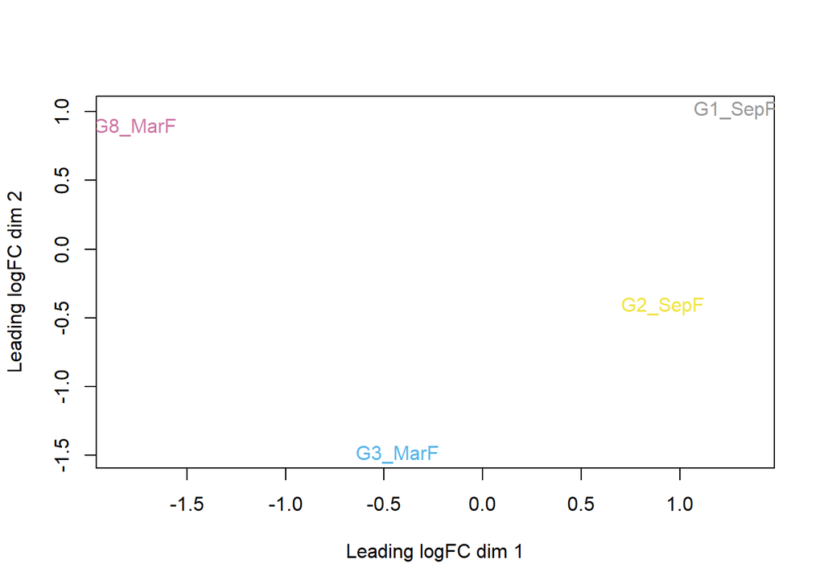

```r
plotMDS(dge_Season4F, col = myPalette4)
```

### Differentially Expressed Genes:

View the top ten ‘differentially expressed genes’

```r
results_Season4F <- exactTest(dge_Season4F)
topTags(results_Season4F)
```

```
## Comparison of groups:  2-1
##                                                     Length EffectiveLength
## PB.4138.1|9a0bd1|path6:1-1549(+)|transcript/20634     1416       1093.7106
## PB.5398.2|cbf34d|path5:582-2207(+)|transcript/17939   1601       1278.7106
## PB.2869.1|6b0af0|path2:1-1117(+)|transcript/22387     1086        763.7106
## PB.4931.3|b8571c|path20:38-3608(+)|transcript/1966    3487       3164.7106
## PB.9559.1|transcript/7471:1-2422(+)|transcript/7471   2391       2068.7106
## PB.876.2|206df6|path10:20-1995(+)|transcript/12799    2024       1701.7106
## PB.3850.1|906dad|path20:1-2023(+)|transcript/12300    1942       1619.7106
## PB.879.1|206df6|path7:41-2171(+)|transcript/12507     1871       1548.7106
## PB.499.11|124cf9|path4:2108-4109(+)|transcript/7418   2000       1677.7106
## PB.4804.1|b3ae52|path0:150-1779(+)|transcript/17853   1574       1251.7106
##                                                     Overdispersion     logFC
## PB.4138.1|9a0bd1|path6:1-1549(+)|transcript/20634         2.095136  8.181660
## PB.5398.2|cbf34d|path5:582-2207(+)|transcript/17939       2.388134 -7.324372
## PB.2869.1|6b0af0|path2:1-1117(+)|transcript/22387         1.000000 -3.952345
## PB.4931.3|b8571c|path20:38-3608(+)|transcript/1966        5.321449  7.096853
## PB.9559.1|transcript/7471:1-2422(+)|transcript/7471       1.078024 -3.886336
## PB.876.2|206df6|path10:20-1995(+)|transcript/12799        7.027709  3.950243
## PB.3850.1|906dad|path20:1-2023(+)|transcript/12300        1.019013 -4.330238
## PB.879.1|206df6|path7:41-2171(+)|transcript/12507        16.000678  9.507562
## PB.499.11|124cf9|path4:2108-4109(+)|transcript/7418       1.582753 -3.241687
## PB.4804.1|b3ae52|path0:150-1779(+)|transcript/17853       1.137449 -3.511822
##                                                       logCPM       PValue
## PB.4138.1|9a0bd1|path6:1-1549(+)|transcript/20634   4.329581 2.337337e-25
## PB.5398.2|cbf34d|path5:582-2207(+)|transcript/17939 4.355781 6.015218e-15
## PB.2869.1|6b0af0|path2:1-1117(+)|transcript/22387   5.424124 1.182776e-13
## PB.4931.3|b8571c|path20:38-3608(+)|transcript/1966  1.923894 3.949696e-13
## PB.9559.1|transcript/7471:1-2422(+)|transcript/7471 4.131625 4.351701e-13
## PB.876.2|206df6|path10:20-1995(+)|transcript/12799  3.719088 1.367118e-12
## PB.3850.1|906dad|path20:1-2023(+)|transcript/12300  3.312113 1.460823e-11
## PB.879.1|206df6|path7:41-2171(+)|transcript/12507   2.115742 3.494145e-11
## PB.499.11|124cf9|path4:2108-4109(+)|transcript/7418 4.879667 4.564669e-11
## PB.4804.1|b3ae52|path0:150-1779(+)|transcript/17853 6.485933 1.011724e-10
##                                                              FDR
## PB.4138.1|9a0bd1|path6:1-1549(+)|transcript/20634   2.293628e-21
## PB.5398.2|cbf34d|path5:582-2207(+)|transcript/17939 2.951367e-11
## PB.2869.1|6b0af0|path2:1-1117(+)|transcript/22387   3.868859e-10
## PB.4931.3|b8571c|path20:38-3608(+)|transcript/1966  8.540648e-10
## PB.9559.1|transcript/7471:1-2422(+)|transcript/7471 8.540648e-10
## PB.876.2|206df6|path10:20-1995(+)|transcript/12799  2.235922e-09
## PB.3850.1|906dad|path20:1-2023(+)|transcript/12300  2.047865e-08
## PB.879.1|206df6|path7:41-2171(+)|transcript/12507   4.286006e-08
## PB.499.11|124cf9|path4:2108-4109(+)|transcript/7418 4.977011e-08
## PB.4804.1|b3ae52|path0:150-1779(+)|transcript/17853 9.928051e-08
```

```r
tab_Season4F <- topTags(results_Season4F)
write.table(tab_Season4F, file = "Kgenelist-Top25_Season4F.txt")
```

Output summary expression data

```r
dim(results_Season4F)
```

```
## [1] 9813    3
```

```r
summary(de_Season4F <- decideTests(results_Season4F))
```

```
##         2-1
## Down    133
## NotSig 9612
## Up       68
```

```r
Summary_Season4F <- (de_Season4F <- decideTests(results_Season4F))

write.table(Summary_Season4F, file = "summary_Season4F.txt")

detags_Season4F <- rownames(dge_Season4F)[as.logical(de_Season4F)]
```

Visualise with a plotsmear

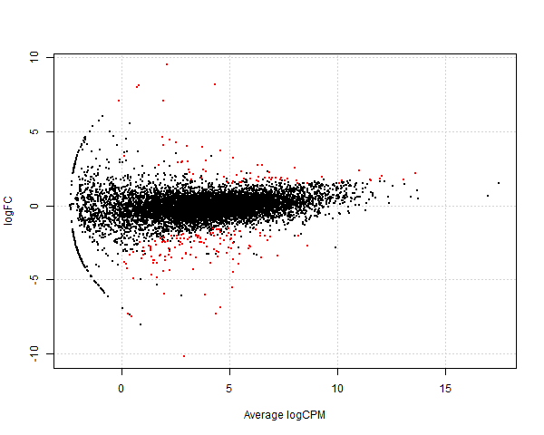

Log Fold Change vs average Log counts per million for expression level comparing March to September among four *T. adelaidensis* individuals. Red dots indicate transcripts with a significant change over season, with p-values <0.05. Counts calculated using Kallisto and EdgeR, for short-read poly(A) selected mRNA sequenced from kidney tissue of four female *Tiliqua adelaidensis* individuals, two collected in autumn and two collected in spring, sequenced using Illumina Hi-Seq PE short-read sequencing. Reference sequence isolated from *Tiliqua adelaidensis* skink ID: G6, a representative individual for Pacific Biosciences Iso-Seq long-read transcript sequencing and annotation to generate full length reference transcripts (note G6 was male).

```r
detags_Season4F <- rownames(dge_Season4F)[as.logical(de_Season4F)]
# export the plot as png
png("plotSmear_Season4F.png", width = 600)
plotSmear(results_Season4F, de.tags = detags_Season4F)
```

Visualise with a volcano plot

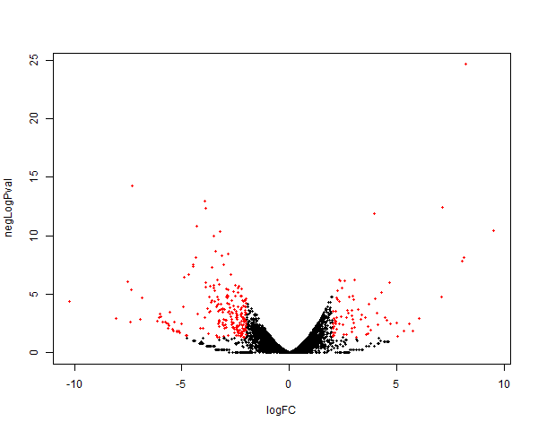

Negative Log of the p-value against Log Fold Change in expression level comparing March to September among four *T. adelaidensis* individuals. Red dots indicate transcripts with a significant change over season, with p-values <0.05 and *also* a log fold change >2. Counts calculated using Kallisto and EdgeR, for short-read poly(A) selected mRNA sequenced from kidney tissue of four female *Tiliqua adelaidensis* individuals, two collected in autumn and two collected in spring, sequenced using Illumina Hi-Seq PE short-read sequencing. Reference sequence isolated from *Tiliqua adelaidensis* skink ID: G6, a representative individual for Pacific Biosciences Iso-Seq long-read transcript sequencing and annotation to generate full length reference transcripts (note G6 was male).

```r
# export the plot as png
png("volcanoData_Season4F.png", width = 600)
volcanoData_Season4F <- cbind(results_Season4F$table$logFC, -log10(results_Season4F$table$PValue))
colnames(volcanoData_Season4F) <- c("logFC", "negLogPval")
DEGs_Season4F <- results_Season4F$table$PValue < 0.05 & abs(results_Season4F$table$logFC) >
    2
point.col_Season4F <- ifelse(DEGs_Season4F, "red", "black")
plot(volcanoData_Season4F, pch = 16, col = point.col_Season4F,
    cex = 0.5)
```